# Workflow Linear Models I

### Step 4: Goodness of fit

#### Outliers and unexpected structure or nonlinearity

Let’s have another look at the residuals vs fitted plot as well as response vs residuals.

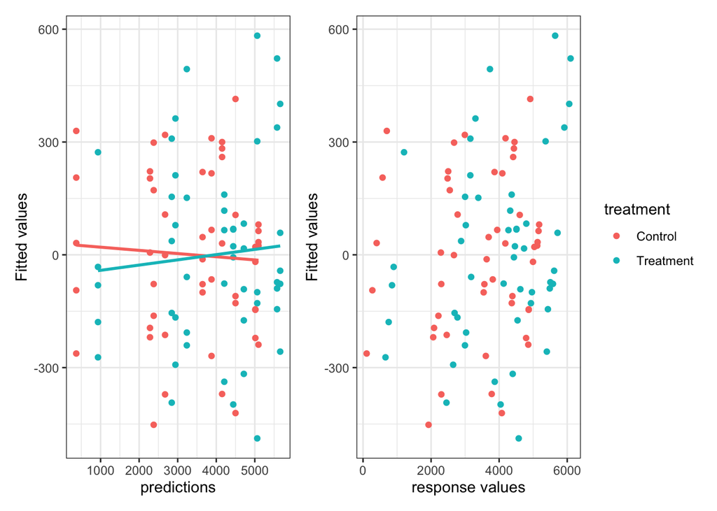

```r
ggplot(data6, aes(
  x = predict(mixed_model),
  y = residuals(mixed_model),
  col = treatment)) +
  geom_point() +
  geom_smooth(se = FALSE, method = "lm") +
  labs(x = "predictions", y = "Fitted values") +
  theme(legend.position = "none") +
  ggplot(data6, aes(
  x = response,
  y = residuals(mixed_model),
  col = treatment)) +
  geom_point() +
  labs(x = "response values", y = "Fitted values")
```

There is some remaining structure in the control and treatment slopes, however this is likely due to this graph not having accounted for the individual repetitions.

As we can see in the plot above, there is no evidence of outliers, unexplained structure or non linearity. Notice the predicted scores are falling out into 20 discrete vertical patterns of 5 points. This is expected since we had 5 repeated measures for 10 patients over 2 treatments.

Let’s also have a look at the response vs predicted graph:

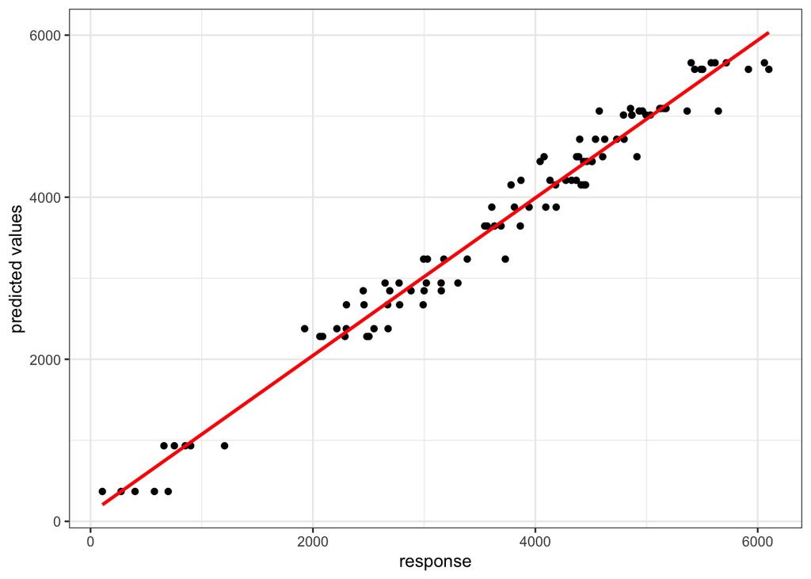

```r
ggplot(data6, aes(x = response, y = predict(mixed_model)), col = id) +
  geom_point() +
  labs(y = "predicted values") +
  geom_smooth(method = "lm", se = FALSE, col = "red")
```

We should also check response vs residuals as well as predict vs. residuals:

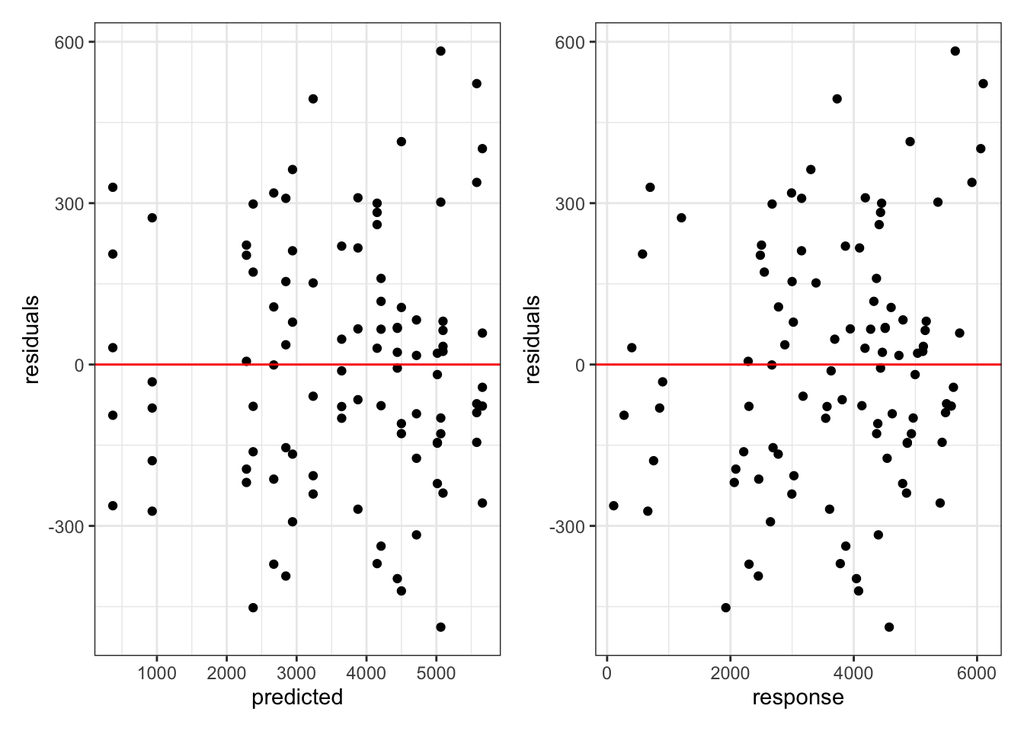

```r
ggplot(data6, aes(x = predict(mixed_model), y = residuals(mixed_model))) +
  geom_point() +
  geom_hline(yintercept = 0, col = "red") +
  labs(y = "residuals", x = "predicted") +
  ggplot(data6, aes(x = response, y = residuals(mixed_model))) +
  geom_point() +
  geom_hline(yintercept = 0, col = "red") +
  labs(y = "residuals") +
  plot_layout(guides = "collect")
```

After assessing the model diagnostics, let’s look at the summary output.